# Reproducible Research: Peer Assessment 1

## Loading and preprocessing the data

This assumes all files from the repository are synched and present in the working directory.

First, unzip the data files.

```r
unzip("activity.zip")
```

Next, read in the activity data file and view some summary information.

```r
activity <- read.csv("activity.csv", header = TRUE)
str(activity)
```

```
## 'data.frame':    17568 obs. of  3 variables:
##  $ steps   : int  NA NA NA NA NA NA NA NA NA NA ...
##  $ date    : Factor w/ 61 levels "2012-10-01","2012-10-02",..: 1 1 1 1 1 1 1 1 1 1 ...
##  $ interval: int  0 5 10 15 20 25 30 35 40 45 ...
```

```r
summary(activity)
```

```
##      steps                date          interval
##  Min.   :  0.00   2012-10-01:  288   Min.   :   0.0
##  1st Qu.:  0.00   2012-10-02:  288   1st Qu.: 588.8
##  Median :  0.00   2012-10-03:  288   Median :1177.5
##  Mean   : 37.38   2012-10-04:  288   Mean   :1177.5
##  3rd Qu.: 12.00   2012-10-05:  288   3rd Qu.:1766.2
##  Max.   :806.00   2012-10-06:  288   Max.   :2355.0
##  NA's   :2304     (Other)   :15840
```

The date field was read in as a factor. Convert it to a date.

```r
library(lubridate)
activity$date <- ymd(activity$date)
```

The data set is now ready for analysis.

## What is mean total number of steps taken per day?

The ddply function from the plyr package can sum the steps per day so that the mean and median are easy to calculate.

First, a quick visualization of the data in the form of a histogram of total steps by day.

```r
library(plyr)
library(ggplot2)
```

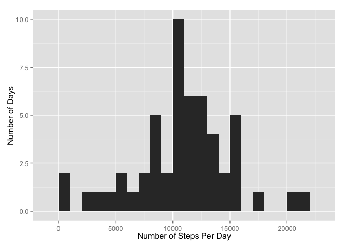

```r
qplot(ddply(activity, .(date), summarise, totsteps = sum(steps))[,2],
      na.rm = TRUE, geom = "histogram", xlab = "Number of Steps Per Day",
      ylab = "Number of Days", binwidth = 1000)
```

```r
mean(ddply(activity, .(date), summarise, totsteps = sum(steps))[,2], na.rm = TRUE)
```

```
## [1] 10766.19
```

```r
median(ddply(activity, .(date), summarise, totsteps = sum(steps))[,2], na.rm = TRUE)
```

```
## [1] 10765
```

## What is the average daily activity pattern?

A plot of the data showing the steps per interval will illustrate the daily activity pattern.

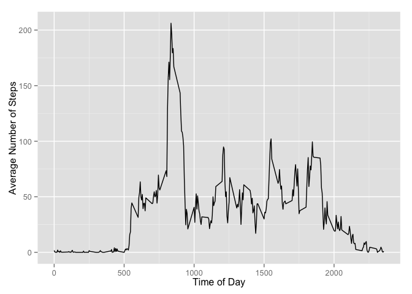

```r
library(ggplot2)
steps <- ddply(activity, .(interval), summarise, totsteps = mean(steps, na.rm = TRUE))
qplot(interval, totsteps, data = steps, geom = "line") +
        theme(legend.position = "none") +
        xlab("Time of Day") +
        ylab("Average Number of Steps")
```

The plot shows an average day starting between 05:30 and 06:00 with a flurry of activity that tapers off around 10:00. The highest average number of steps occurs between 08:35 and 08:40. The day maintains a relative steady-state of activity, slightly increasing through the afternoon. The activity level declines dramatically into the evening, and by 21:00 is very low for the rest of the night.

## Imputing missing values

The data set is missing 2304 values. The missing values will be substituted with imputed values using a median function for each value’s interval in the sample.

```r
sum(is.na(activity$steps)) # Calculate number of NA values
```

```
## [1] 2304
```

```r
mediansteps <- ddply(activity, .(interval), summarise, mediansteps = median(steps, na.rm = TRUE))
for (i in 1:dim(activity)[1]) {
        if (is.na(activity[i, "steps"])) {
                activity[i, "steps"] <- mediansteps[mediansteps$interval == activity[i, "interval"], "mediansteps"]
        }
}
```

With the imputed values, the mean and median are now 9503.8688525 and 10395.

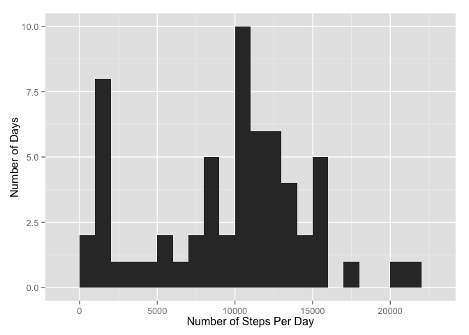

```r
qplot(ddply(activity, .(date), summarise, totsteps = sum(steps))[,2],
      na.rm = TRUE, geom = "histogram", xlab = "Number of Steps Per Day",
      ylab = "Number of Days", binwidth = 1000)
```

```r
mean(ddply(activity, .(date), summarise, totsteps = sum(steps))[,2], na.rm = TRUE)
```

```
## [1] 9503.869
```

```r
median(ddply(activity, .(date), summarise, totsteps = sum(steps))[,2], na.rm = TRUE)
```

```
## [1] 10395
```

The new values are lower than the values calculated excluding the imputed data.

## Are there differences in activity patterns between weekdays and weekends?

To understand the difference between weekdays and weekends, a new variable to indicate weekday or weekend is added to the data set. Then a plot comparing the two can be constructed.

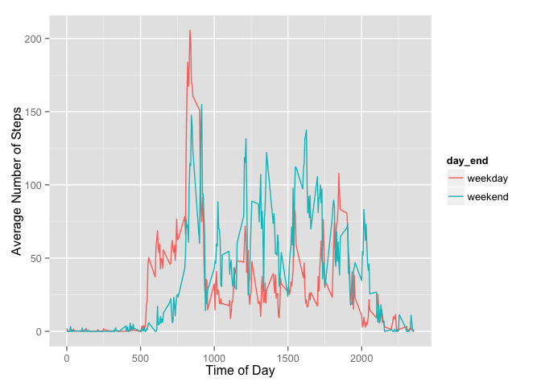

```r
activity[weekdays(activity$date)
         %in% c("Monday", "Tuesday", "Wednesday",
                "Thursday", "Friday"), "day_end"] <- "weekday"
activity[weekdays(activity$date)
         %in% c("Saturday", "Sunday"), "day_end"] <- "weekend"
steps <- ddply(activity, .(interval, day_end), summarise, totsteps = mean(steps, na.rm = TRUE))
qplot(interval, totsteps, data = steps, geom = "line", color = day_end) +
        xlab("Time of Day") +
        ylab("Average Number of Steps")
```

When the two series are plotted together, it is easy to see that weekend days are more active, and start and end later than week days.